# Chapter 9 Beta diversity

Between-sample dissimilarity using Hill-based distances (richness, neutral, phylogenetic, functional), PERMANOVA tests for broad environment/island effects, and NMDS ordinations to visualise separation in community structure.

**Note:** Load all required data objects including genome counts, metadata, and color schemes.

```r
load("data/data.Rdata")

treatment_colors <- c("#f56042","#429ef5", "#42f58d", "#b142f5", "#f5e642")
```

**Note:** Filter out sample EHI01340, identify valid samples, remove samples with missing broad_environment values, and filter genome counts to only include valid samples.

```r
sample_metadata <- sample_metadata %>% dplyr::filter(sample != "EHI01340")
valid_samples <- sample_metadata$sample

sample_metadata_without_NA <- sample_metadata %>%
  dplyr::filter(!is.na(broad_environment))

genome_counts_filt <- genome_counts_filt %>%
  dplyr::select(genome, tidyselect::any_of(valid_samples))
```

*beta_div*

**Note:** Calculate four types of beta diversity distance matrices using Hill-based pairwise distances: richness-based (q=0, presence/absence), neutral/abundance-weighted (q=1), phylogenetic (q=1 with phylogenetic tree), and functional (q=1 with functional trait distances). Filters out genomes and samples with zero counts before calculation.

```r
restore_beta_sample_labels <- function(beta_obj, sample_ids) {
  beta_mat <- as.matrix(beta_obj$S)
  rownames(beta_mat) <- colnames(beta_mat) <- sample_ids
  beta_obj$S <- stats::as.dist(beta_mat)
  beta_obj
}

counts_for_beta <- genome_counts_filt %>%
  tibble::column_to_rownames("genome") %>%
  dplyr::filter(rowSums(. != 0, na.rm = TRUE) > 0) %>%
  dplyr::select_if(~!all(. == 0))
sample_ids <- colnames(counts_for_beta)

# Presence/Absence
beta_q0n <- counts_for_beta %>%
  hillpair(., q = 0) %>%
  restore_beta_sample_labels(., sample_ids)

# Abundance-sensitive
beta_q1n <- counts_for_beta %>%
  hillpair(., q = 1) %>%
  restore_beta_sample_labels(., sample_ids)

# Abundance + Phylogeny
genome_counts_filt_beta <- counts_for_beta %>%
  tibble::rownames_to_column("genome")
genome_tree_beta <- keep.tip(genome_tree, tip = genome_counts_filt_beta$genome)
beta_q1p <- counts_for_beta %>%
  hillpair(., q = 1, tree = genome_tree_beta) %>%
  restore_beta_sample_labels(., sample_ids)
```

**Note:** Calculate functional beta diversity (beta_q1f) by matching genomes between count data and functional trait data (genome_gifts). Converts GIFT traits to elements, calculates Gower distance matrix, filters and aligns both datasets to common genomes, then computes Hill-based pairwise distances with functional trait distances.

```r
# Create genome_counts_filt_beta if it doesn't exist (from beta_div chunk)
if (!exists("genome_counts_filt_beta")) {
  genome_counts_filt_beta <- genome_counts_filt %>%
    tibble::column_to_rownames(., "genome") %>%
    dplyr::filter(rowSums(. != 0, na.rm = TRUE) > 0) %>%
    dplyr::select_if(~!all(. == 0)) %>%
    tibble::rownames_to_column(., "genome")
}

# 1. Only use genomes that also occur in genome_gifts
valid_genomes <- genome_counts_filt_beta$genome[genome_counts_filt_beta$genome %in% rownames(genome_gifts)]

# 2. filter genome_gifts on these genomes
genome_gifts1 <- genome_gifts[valid_genomes, ]
genome_gifts1 <- genome_gifts1[, colSums(genome_gifts1 != 0) > 0]

# 3. Calculate functional distance matrix
dist <- genome_gifts1 %>%
  to.elements(., GIFT_db) %>%
  traits2dist(., method = "gower")

# 4. Determine genomes that exist in both genome_counts_filt_beta and dist
common_genomes <- intersect(
  genome_counts_filt_beta$genome,
  rownames(dist)
)

# 5. Align count matrix rows to dist matrix order (common_genomes)
genome_counts_filt_matched <- genome_counts_filt %>%
  dplyr::filter(genome %in% common_genomes) %>%
  dplyr::mutate(genome = factor(genome, levels = common_genomes)) %>%
  dplyr::arrange(genome) %>%
  tibble::column_to_rownames("genome") %>%
  dplyr::select_if(~!all(. == 0))

# 6. Limit and sort dist matrix to common genomes
dist_matched <- dist[common_genomes, common_genomes]

beta_q1f <- genome_counts_filt_matched %>%
  hillpair(q = 1, dist = dist_matched)

beta_q1f <- restore_beta_sample_labels(beta_q1f, colnames(genome_counts_filt_matched))
```

**Note:** Save all four beta diversity distance matrices (richness, neutral, phylogenetic, functional) to an R data file for later use.

**Note:** Set random seed for reproducibility of permutation-based statistical tests.

## 9.1 Permanova

**Note:** Define a reusable function `run_permanova` that performs PERMANOVA analysis on beta diversity matrices. The function matches samples between distance matrix and metadata, filters out NAs, tests beta dispersion (homogeneity of variances), runs PERMANOVA with adonis2, optionally performs pairwise comparisons, and returns both dispersion and PERMANOVA results.

```r
run_permanova <- function(beta_matrix,
                          metadata,
                          sample_col = "sample",
                          group_col,
                          group_vars,
                          pairwise = FALSE) {

  # 1. Sample labels from Beta-Matrix (dist object)
  sample_labels <- labels(beta_matrix$S)

  # 2. Metadata filtered and sorted
  metadata_matched <- metadata %>%
    dplyr::filter(!!rlang::sym(sample_col) %in% sample_labels) %>%
    dplyr::arrange(match(!!rlang::sym(sample_col), sample_labels))

  # 3. Synchronize beta_matrix$S to metadata (subset via matrix, then back to dist)
  common_samples <- intersect(sample_labels, metadata_matched[[sample_col]])

  S_mat <- as.matrix(beta_matrix$S)
  S_mat <- S_mat[common_samples, common_samples, drop = FALSE]
  beta_matrix$S <- as.dist(S_mat)

  metadata_matched <- metadata_matched %>%
    dplyr::filter(!!rlang::sym(sample_col) %in% common_samples) %>%
    dplyr::arrange(match(!!rlang::sym(sample_col), common_samples))

  # 4. Remove samples with NA in group_col (again via matrix → dist)
  valid_idx <- !is.na(metadata_matched[[group_col]])

  S_mat <- as.matrix(beta_matrix$S)
  S_mat <- S_mat[valid_idx, valid_idx, drop = FALSE]
  beta_matrix$S <- as.dist(S_mat)

  metadata_matched <- metadata_matched[valid_idx, ]

  n_groups <- length(unique(metadata_matched[[group_col]]))
  if (n_groups < 2L) {
    warning(
      "Skipping PERMANOVA: '", group_col, "' has ", n_groups,
      " level(s) after matching (", nrow(metadata_matched), " samples)."
    )
    return(list(dispersion = NULL, permanova = NULL))
  }

  # 5. Betadisper and Permutest
  cat("\n===== Beta Dispersion Test =====\n")
  dispersion_result <- betadisper(beta_matrix$S, metadata_matched[[group_col]])
  print(permutest(dispersion_result))

  # 6. Dynamic formula building
  formula_str <- paste0("beta_matrix$S ~ ", paste(group_vars, collapse = " + "))
  cat("\n===== PERMANOVA Test (adonis2) =====\n")
  permanova_result <- adonis2(
    as.formula(formula_str),
    data = metadata_matched,
    permutations = 999,
    by = "terms"
  )
  print(broom::tidy(permanova_result))

  # 7. (Optional) Pairwise Adonis
  if (pairwise) {
    cat("\n===== Pairwise PERMANOVA =====\n")
    print(pairwise.adonis(beta_matrix$S, metadata_matched[[group_col]], perm = 999))
  }

  # 8. Return outputs
  return(list(
    dispersion = dispersion_result,
    permanova  = permanova_result
  ))
}
```

### 9.1.1 Richness

```r
run_permanova(
  beta_matrix = beta_q0n,
  metadata = sample_metadata_without_NA,
  sample_col = "sample",
  group_col = "broad_environment",
  group_vars = c("broad_environment", "island", "broad_environment:island"),
  pairwise = FALSE
)
```

```
===== Beta Dispersion Test =====

Permutation test for homogeneity of multivariate dispersions
Permutation: free
Number of permutations: 999

Response: Distances
          Df  Sum Sq  Mean Sq      F N.Perm Pr(>F)
Groups     4 0.34450 0.086126 24.942    999  0.001 ***
Residuals 67 0.23135 0.003453
---
Signif. codes:  0 '***' 0.001 '**' 0.01 '*' 0.05 '.' 0.1 ' ' 1

===== PERMANOVA Test (adonis2) =====
```

```
# A tibble: 4 × 6
  term                 df SumOfSqs    R2 statistic p.value
  <chr>             <dbl>    <dbl> <dbl>     <dbl>   <dbl>
1 broad_environment     4     3.59 0.135      3.09   0.001
2 island                1     3.93 0.147     13.5    0.001
3 Residual             66    19.2  0.718     NA     NA
4 Total                71    26.7  1         NA     NA
```

```
$dispersion

    Homogeneity of multivariate dispersions

Call: betadisper(d = beta_matrix$S, group = metadata_matched[[group_col]])

No. of Positive Eigenvalues: 71
No. of Negative Eigenvalues: 0

Average distance to median:
       1000198 - Mixed forest 1000215 - Temperate shrubland     1000218 - Xeric shrubland
                       0.4214                        0.4098                        0.4631
 1000221 - Temperate woodland            1000245 - Cropland
                       0.6067                        0.5154

Eigenvalues for PCoA axes:
(Showing 8 of 71 eigenvalues)
 PCoA1  PCoA2  PCoA3  PCoA4  PCoA5  PCoA6  PCoA7  PCoA8
4.3803 2.9152 1.3249 1.2293 1.0689 1.0209 0.8381 0.7413

$permanova
Permutation test for adonis under reduced model
Terms added sequentially (first to last)
Permutation: free
Number of permutations: 999

adonis2(formula = as.formula(formula_str), data = metadata_matched, permutations = 999, by = "terms")
                  Df SumOfSqs      R2       F Pr(>F)
broad_environment  4   3.5893 0.13457  3.0922  0.001 ***
island             1   3.9304 0.14736 13.5444  0.001 ***
Residual          66  19.1526 0.71807
Total             71  26.6723 1.00000
---
Signif. codes:  0 '***' 0.001 '**' 0.01 '*' 0.05 '.' 0.1 ' ' 1
```

### 9.1.2 Neutral diversity

```r
run_permanova(
  beta_matrix = beta_q1n,
  metadata = sample_metadata_without_NA,
  sample_col = "sample",
  group_col = "broad_environment",
  group_vars = c("broad_environment", "island", "broad_environment:island"),
  pairwise = TRUE
)
```

```
===== Beta Dispersion Test =====

Permutation test for homogeneity of multivariate dispersions
Permutation: free
Number of permutations: 999

Response: Distances
          Df  Sum Sq  Mean Sq      F N.Perm Pr(>F)
Groups     4 0.45509 0.113773 19.577    999  0.001 ***
Residuals 67 0.38938 0.005812
---
Signif. codes:  0 '***' 0.001 '**' 0.01 '*' 0.05 '.' 0.1 ' ' 1

===== PERMANOVA Test (adonis2) =====
```

```
# A tibble: 4 × 6
  term                 df SumOfSqs    R2 statistic p.value
  <chr>             <dbl>    <dbl> <dbl>     <dbl>   <dbl>
1 broad_environment     4     3.98 0.150      3.54   0.001
2 island                1     4.03 0.152     14.3    0.001
3 Residual             66    18.5  0.698     NA     NA
4 Total                71    26.5  1         NA     NA

===== Pairwise PERMANOVA =====
                                                           pairs Df SumsOfSqs  F.Model
1         1000198 - Mixed forest vs 1000221 - Temperate woodland  1 1.0804112 2.962490
2            1000198 - Mixed forest vs 1000218 - Xeric shrubland  1 1.4984768 6.670622
3                   1000198 - Mixed forest vs 1000245 - Cropland  1 0.8764511 3.489895
4        1000198 - Mixed forest vs 1000215 - Temperate shrubland  1 0.8870810 3.835443
5      1000221 - Temperate woodland vs 1000218 - Xeric shrubland  1 1.4173977 3.901275
```

[output cut: 16 more lines]

```
$dispersion

    Homogeneity of multivariate dispersions

Call: betadisper(d = beta_matrix$S, group = metadata_matched[[group_col]])

No. of Positive Eigenvalues: 66
No. of Negative Eigenvalues: 5

Average distance to median:
       1000198 - Mixed forest 1000215 - Temperate shrubland     1000218 - Xeric shrubland
                       0.4004                        0.4150                        0.4299
 1000221 - Temperate woodland            1000245 - Cropland
                       0.6066                        0.4816

Eigenvalues for PCoA axes:
(Showing 8 of 71 eigenvalues)
 PCoA1  PCoA2  PCoA3  PCoA4  PCoA5  PCoA6  PCoA7  PCoA8
4.6245 3.0398 1.6209 1.4222 1.3367 1.2005 0.9718 0.8621

$permanova
Permutation test for adonis under reduced model
Terms added sequentially (first to last)
Permutation: free
Number of permutations: 999

adonis2(formula = as.formula(formula_str), data = metadata_matched, permutations = 999, by = "terms")
                  Df SumOfSqs      R2       F Pr(>F)
broad_environment  4   3.9778 0.14984  3.5401  0.001 ***
island             1   4.0287 0.15176 14.3412  0.001 ***
Residual          66  18.5404 0.69840
Total             71  26.5469 1.00000
---
Signif. codes:  0 '***' 0.001 '**' 0.01 '*' 0.05 '.' 0.1 ' ' 1
```

### 9.1.3 Phylogenetic diversity (beta_q1p)

```r
run_permanova(
  beta_matrix = beta_q1p,
  metadata = sample_metadata_without_NA,
  sample_col = "sample",
  group_col = "broad_environment",
  group_vars = c("broad_environment", "island", "broad_environment:island"),
  pairwise = FALSE  # no pairwise comparisons here
)
```

```
===== Beta Dispersion Test =====
```

```
Permutation test for homogeneity of multivariate dispersions
Permutation: free
Number of permutations: 999

Response: Distances
          Df  Sum Sq   Mean Sq     F N.Perm Pr(>F)
Groups     4 0.09121 0.0228015 3.313    999  0.021 *
Residuals 67 0.46113 0.0068825
---
Signif. codes:  0 '***' 0.001 '**' 0.01 '*' 0.05 '.' 0.1 ' ' 1

===== PERMANOVA Test (adonis2) =====
```

```
# A tibble: 4 × 6
  term                 df SumOfSqs    R2 statistic p.value
  <chr>             <dbl>    <dbl> <dbl>     <dbl>   <dbl>
1 broad_environment     4    0.866 0.183      4.23   0.001
2 island                1    0.488 0.103      9.54   0.001
3 Residual             66    3.37  0.714     NA     NA
4 Total                71    4.73  1         NA     NA
```

```
$dispersion

    Homogeneity of multivariate dispersions

Call: betadisper(d = beta_matrix$S, group = metadata_matched[[group_col]])

No. of Positive Eigenvalues: 30
No. of Negative Eigenvalues: 41

Average distance to median:
       1000198 - Mixed forest 1000215 - Temperate shrubland     1000218 - Xeric shrubland
                       0.1737                        0.1346                        0.1529
 1000221 - Temperate woodland            1000245 - Cropland
                       0.2407                        0.1862

Eigenvalues for PCoA axes:
(Showing 8 of 71 eigenvalues)
  PCoA1   PCoA2   PCoA3   PCoA4   PCoA5   PCoA6   PCoA7   PCoA8
1.89979 1.58370 0.45215 0.32441 0.24692 0.17542 0.15827 0.09806

$permanova
Permutation test for adonis under reduced model
Terms added sequentially (first to last)
Permutation: free
Number of permutations: 999

adonis2(formula = as.formula(formula_str), data = metadata_matched, permutations = 999, by = "terms")
                  Df SumOfSqs      R2      F Pr(>F)
broad_environment  4   0.8656 0.18312 4.2334  0.001 ***
island             1   0.4876 0.10316 9.5393  0.001 ***
Residual          66   3.3737 0.71372
Total             71   4.7269 1.00000
---
Signif. codes:  0 '***' 0.001 '**' 0.01 '*' 0.05 '.' 0.1 ' ' 1
```

### 9.1.4 Functional diversity (beta_q1f)

```r
run_permanova(
  beta_matrix = beta_q1f,
  metadata = sample_metadata_without_NA,
  sample_col = "sample",
  group_col = "broad_environment",
  group_vars = c("broad_environment", "island", "broad_environment:island"),
  pairwise = TRUE
)
```

```
===== Beta Dispersion Test =====
```

```
Permutation test for homogeneity of multivariate dispersions
Permutation: free
Number of permutations: 999

Response: Distances
          Df  Sum Sq   Mean Sq      F N.Perm Pr(>F)
Groups     4 0.04260 0.0106501 3.4176    999  0.028 *
Residuals 67 0.20879 0.0031163
---
Signif. codes:  0 '***' 0.001 '**' 0.01 '*' 0.05 '.' 0.1 ' ' 1

===== PERMANOVA Test (adonis2) =====
```

```
# A tibble: 4 × 6
  term                 df SumOfSqs       R2 statistic p.value
  <chr>             <dbl>    <dbl>    <dbl>     <dbl>   <dbl>
1 broad_environment     4  0.00176  0.00544    0.0891   0.76
2 island                1 -0.00440 -0.0136    -0.891    0.883
3 Residual             66  0.326    1.01      NA       NA
4 Total                71  0.324    1         NA       NA

===== Pairwise PERMANOVA =====
                                                           pairs Df     SumsOfSqs    F.Model
1         1000198 - Mixed forest vs 1000221 - Temperate woodland  1  0.0163072461  3.5752595
2            1000198 - Mixed forest vs 1000218 - Xeric shrubland  1  0.0019992999  0.1051085
3                   1000198 - Mixed forest vs 1000245 - Cropland  1 -0.0033467911 -0.5153008
4        1000198 - Mixed forest vs 1000215 - Temperate shrubland  1  0.0019150170  0.1359266
5      1000221 - Temperate woodland vs 1000218 - Xeric shrubland  1 -0.0083471005 -1.8455126
```

[output cut: 16 more lines]

```
$dispersion

    Homogeneity of multivariate dispersions

Call: betadisper(d = beta_matrix$S, group = metadata_matched[[group_col]])

No. of Positive Eigenvalues: 34
No. of Negative Eigenvalues: 36

Average distance to median:
       1000198 - Mixed forest 1000215 - Temperate shrubland     1000218 - Xeric shrubland
                     0.085317                      0.004505                      0.098786
 1000221 - Temperate woodland            1000245 - Cropland
                     0.034144                      0.016136

Eigenvalues for PCoA axes:
(Showing 8 of 70 eigenvalues)
    PCoA1     PCoA2     PCoA3     PCoA4     PCoA5     PCoA6     PCoA7     PCoA8
0.5790464 0.0127674 0.0027251 0.0015677 0.0010148 0.0007626 0.0005941 0.0003265

$permanova
Permutation test for adonis under reduced model
Terms added sequentially (first to last)
Permutation: free
Number of permutations: 999

adonis2(formula = as.formula(formula_str), data = metadata_matched, permutations = 999, by = "terms")
                  Df SumOfSqs       R2       F Pr(>F)
broad_environment  4  0.00176  0.00544  0.0891  0.760
island             1 -0.00440 -0.01361 -0.8909  0.883
Residual          66  0.32624  1.00817
Total             71  0.32360  1.00000
```

## 9.2 NMDS

NMDS of β-diversity (richness/neutral/phylogenetic/functional). Points are samples, coloured by broad environment and shaped by island; segments draw each point to its group centroid.

**Note:** Define a reusable function to create NMDS ordination plots. The function performs metaMDS on the distance matrix, extracts NMDS scores, joins with sample metadata, calculates group centroids, and visualizes samples with optional labels.

```r
# Function to fit NMDS once per beta matrix (reused for limits and plotting)
fit_nmds_ordination <- function(beta_matrix, seed = 2025L) {
  set.seed(seed)
  nmds_obj <- beta_matrix$S %>%
    vegan::metaMDS(trymax = 500, k = 2, trace = 0)
  list(nmds_obj = nmds_obj, stress = nmds_obj$stress)
}

# Function to calculate overall axis limits from all beta matrices
calculate_nmds_limits <- function(beta_matrices, seed = 2025L) {
  nmds_fits <- purrr::imap(beta_matrices, function(beta_mat, name) {
    fit <- fit_nmds_ordination(beta_mat, seed = seed)
    fit$name <- name
    fit
  })
  names(nmds_fits) <- names(beta_matrices)

  all_scores <- purrr::map_dfr(nmds_fits, function(fit) {
    fit$nmds_obj %>%
      vegan::scores() %>%
      tibble::as_tibble(rownames = "sample")
  })

  x_range <- range(all_scores$NMDS1, na.rm = TRUE)
  y_range <- range(all_scores$NMDS2, na.rm = TRUE)

  # Add some padding (5% on each side)
  x_padding <- diff(x_range) * 0.05
  y_padding <- diff(y_range) * 0.05

  list(
    xlim = c(x_range[1] - x_padding, x_range[2] + x_padding),
    ylim = c(y_range[1] - y_padding, y_range[2] + y_padding),
    fits = nmds_fits
  )
}

create_nmds_plot <- function(beta_matrix,
                             show_labels = FALSE,
                             point_size = 3,
                             segment_alpha = 0.3,
                             show_ellipses = FALSE,
                             show_centroids = TRUE,
                             xlim = NULL,
                             ylim = NULL,
                             nmds_obj = NULL) {
  env_nmds_labels <- c(
    "1000198 - Mixed forest" = "Mixed forest (MF)",
    "1000221 - Temperate woodland" = "Temperate woodland (TW)",
    "1000218 - Xeric shrubland" = "Xeric shrubland (XS)",
    "1000215 - Temperate shrubland" = "Temperate shrubland (TS)",
    "1000245 - Cropland" = "Cropland (C)"
  )
  env_nmds_levels <- names(env_nmds_labels)

  if (is.null(nmds_obj)) {
    nmds_obj <- fit_nmds_ordination(beta_matrix)$nmds_obj
  }

  stress_value <- nmds_obj$stress

  # Extract scores and join with metadata
  nmds_scores <- nmds_obj %>%
    vegan::scores() %>%
    tibble::as_tibble(rownames = "sample") %>%
    dplyr::inner_join(sample_metadata, by = join_by(sample == sample)) %>%
    group_by(broad_environment) %>%
    mutate(
      x_cen = mean(NMDS1, na.rm = TRUE),
      y_cen = mean(NMDS2, na.rm = TRUE)
    ) %>%
    ungroup()

  # Create base plot
  p <- nmds_scores %>%
    ggplot(aes(x = NMDS1, y = NMDS2,
               color = broad_environment,
               shape = as.factor(island))) +
    # Add segments from centroids to points (lighter and thinner)
    geom_segment(
      aes(x = x_cen, y = y_cen, xend = NMDS1, yend = NMDS2),
      alpha = segment_alpha,
      linewidth = 0.3,
      color = "gray60",
      show.legend = FALSE
    ) +
    # Add sample points
    geom_point(size = point_size, alpha = 0.8) +
    # Color scale by broad environment
    scale_color_manual(
      values = treatment_colors,
      labels = env_nmds_labels,
      breaks = env_nmds_levels,
      name = "Environment"
    ) +
    # Shape scale
    scale_shape_discrete(name = "Island")

  # Add confidence ellipses if requested
  if (show_ellipses) {
    p <- p + stat_ellipse(
      aes(color = broad_environment),
      type = "norm",
      level = 0.95,
      linetype = 2,
      alpha = 0.5,
      linewidth = 0.5,
      show.legend = FALSE
    )
  }

  # Add centroid markers if requested
  if (show_centroids) {
    p <- p + geom_point(
      data = nmds_scores %>%
        dplyr::distinct(broad_environment, x_cen, y_cen),
      aes(x = x_cen, y = y_cen, color = broad_environment),
      shape = 21,
      size = 6,
      stroke = 2,
      fill = "white",
      show.legend = FALSE
    )
  }

  # Add theme and labels
  p <- p +
    # Theme
    theme(
      axis.title = element_text(size = 12, face = "bold"),
      axis.text = element_text(size = 10),
      panel.background = element_blank(),
      panel.grid.major = element_line(color = "gray90", linewidth = 0.3),
      panel.grid.minor = element_blank(),
      axis.line = element_line(size = 0.5, linetype = "solid", colour = "black"),
      legend.text = element_text(size = 10),
      legend.title = element_text(size = 11, face = "bold"),
      legend.position = "right",
      legend.box = "vertical",
      legend.spacing = unit(0.5, "cm"),
      legend.key.size = unit(1, "lines")
    ) +
    # Labels with stress value in title
    labs(
      title = paste0("NMDS (Stress = ", round(stress_value, 3), ")"),
      x = "NMDS1",
      y = "NMDS2",
      color = "Environmental context",
      shape = "Island"
    ) +
    # Legend guides
    guides(
      color = guide_legend(order = 1, override.aes = list(size = 3)),
      shape = guide_legend(order = 2, override.aes = list(size = 3))
    )

  # Add coordinate system with fixed limits if provided
  if (!is.null(xlim) && !is.null(ylim)) {
    p <- p + coord_fixed(ratio = 1, xlim = xlim, ylim = ylim, expand = TRUE)
  } else {
    p <- p + coord_fixed(ratio = 1, expand = TRUE)
  }

  # Text labels removed - no longer adding sample IDs

  return(p)
}
```

**Note:** Calculate overall axis limits from all beta diversity matrices to ensure consistent scaling across all NMDS plots.

```r
# Calculate limits once from all beta matrices (single NMDS fit per matrix)
nmds_result <- calculate_nmds_limits(list(
  beta_q0n = beta_q0n,
  beta_q1n = beta_q1n,
  beta_q1p = beta_q1p,
  beta_q1f = beta_q1f
))
nmds_limits <- nmds_result[c("xlim", "ylim")]
nmds_fits <- nmds_result$fits
```

**Note:** Create NMDS ordination plot for richness-based beta diversity. Performs metaMDS on the distance matrix, extracts NMDS scores, joins with sample metadata, calculates group centroids for each broad environment, and visualizes samples colored by environment and shaped by island, with segments connecting samples to their group centroids.

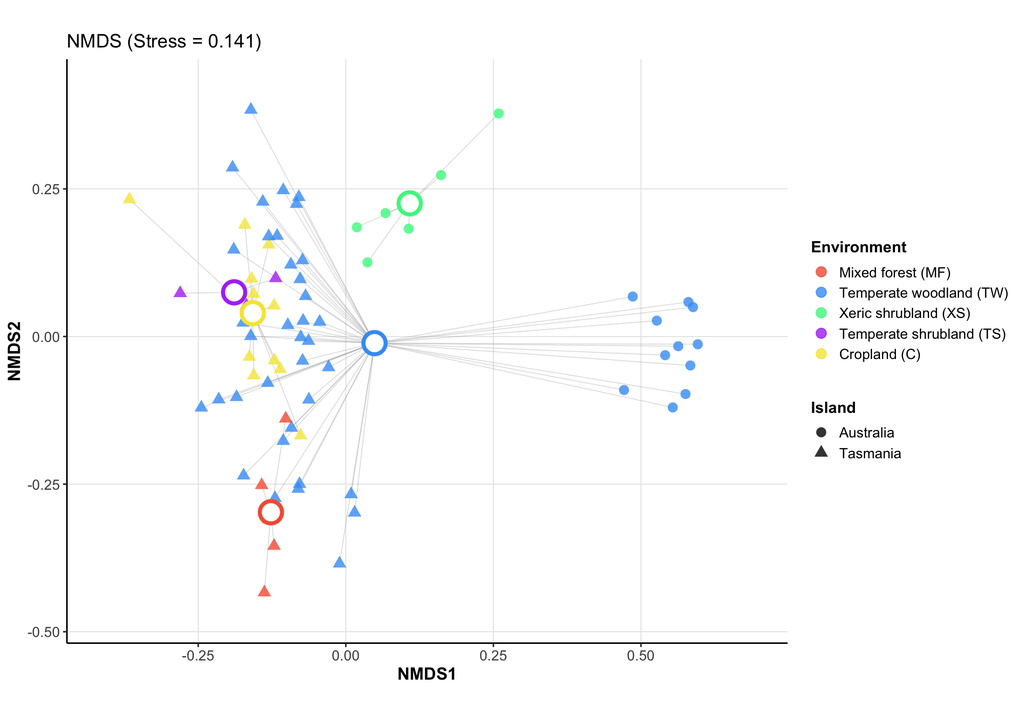

```r
create_nmds_plot(beta_q0n,
                 show_labels = FALSE,
                 xlim = nmds_limits$xlim,
                 ylim = nmds_limits$ylim,
                 nmds_obj = nmds_fits$beta_q0n$nmds_obj)
```

### 9.2.1 Neutral diversity

**Note:** Create NMDS ordination plot for abundance-weighted beta diversity. Performs metaMDS on the distance matrix, extracts NMDS scores, joins with sample metadata, calculates group centroids for each broad environment, and visualizes samples colored by environment and shaped by island, with segments connecting samples to their group centroids.

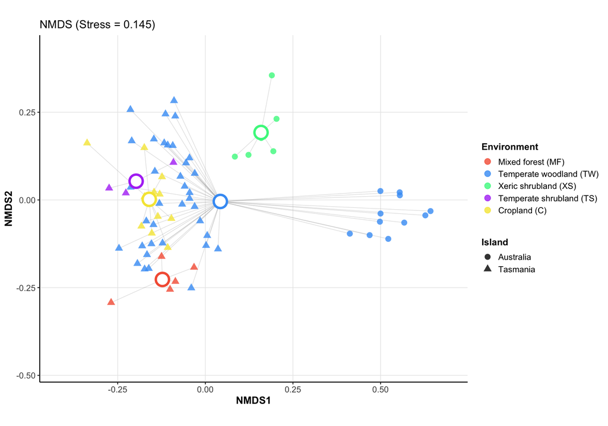

```r
create_nmds_plot(beta_q1n,
                 show_labels = FALSE,
                 xlim = nmds_limits$xlim,
                 ylim = nmds_limits$ylim,
                 nmds_obj = nmds_fits$beta_q1n$nmds_obj)
```

### 9.2.2 Phylogenetic diversity

**Note:** Create NMDS ordination plot for phylogenetic beta diversity. Performs metaMDS on the distance matrix, extracts NMDS scores, joins with sample metadata, calculates group centroids for each broad environment, and visualizes samples colored by environment and shaped by island, with segments connecting samples to their group centroids.

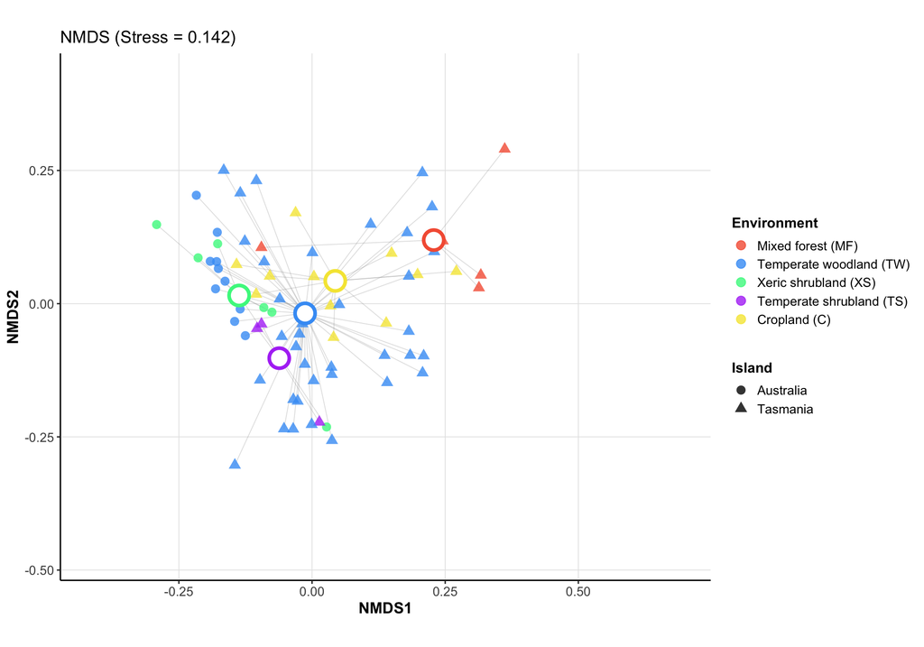

```r
create_nmds_plot(beta_q1p,
                 show_labels = FALSE,
                 xlim = nmds_limits$xlim,
                 ylim = nmds_limits$ylim,
                 nmds_obj = nmds_fits$beta_q1p$nmds_obj)
```

### 9.2.3 Functional diversity

**Note:** Create NMDS ordination plot for functional beta diversity. Performs metaMDS on the distance matrix, extracts NMDS scores, joins with sample metadata, calculates group centroids for each broad environment, and visualizes samples colored by environment and shaped by island, with segments connecting samples to their group centroids.

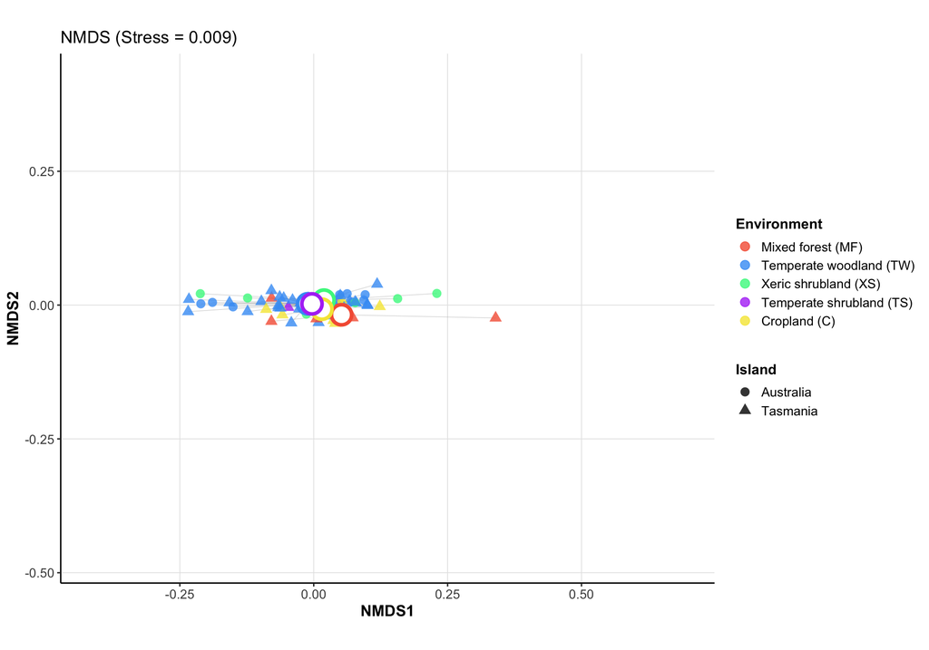

```r
create_nmds_plot(beta_q1f,
                 show_labels = FALSE,
                 xlim = nmds_limits$xlim,
                 ylim = nmds_limits$ylim,
                 nmds_obj = nmds_fits$beta_q1f$nmds_obj)
```

**Note:** Create a zoomed-in version of the functional diversity NMDS plot with axes fitted to the data range for better visualization of the functional diversity patterns. The y-axis is stretched with additional padding for improved visibility.

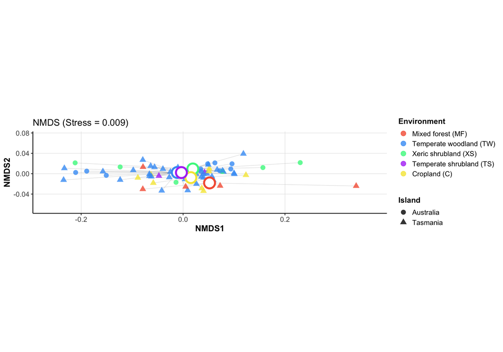

```r
# Calculate functional diversity specific limits with more y-axis padding
func_nmds_obj <- nmds_fits$beta_q1f$nmds_obj

func_scores <- func_nmds_obj %>%
  vegan::scores() %>%
  tibble::as_tibble(rownames = "sample")

x_range_func <- range(func_scores$NMDS1, na.rm = TRUE)
y_range_func <- range(func_scores$NMDS2, na.rm = TRUE)

# Add padding: 5% for x-axis, 15% for y-axis (more stretch on y)
x_padding_func <- diff(x_range_func) * 0.05
y_padding_func <- diff(y_range_func) * 0.50

func_limits <- list(
  xlim = c(x_range_func[1] - x_padding_func, x_range_func[2] + x_padding_func),
  ylim = c(y_range_func[1] - y_padding_func, y_range_func[2] + y_padding_func)
)

create_nmds_plot(beta_q1f,
                 show_labels = FALSE,
                 xlim = func_limits$xlim,
                 ylim = func_limits$ylim)
```

**Note:** Save precomputed objects for chapter 15 (sample set, alpha diversity, NMDS limits). Requires `landcover_wide.csv` from chapter 5; skipped if land cover is not yet available.